# PERMANOVA

Gavin Simpson

May 31, 2024

# Effect of ploughing time on weeds

Post (1986) carried out an experiment to investigate the effect of time of ploughing on the subsequent weed composition in summer barley fields. Three different ploughing times were used. There are 13 weed species observed in 12 plots in a randomized block experiment of four complete blocks of three plots each.

```r
library("vegan")
library("dplyr")
library("readr")

plough <- read_csv(url("https://bit.ly/plough-spp"), skip = 1) %>%
    rename(label = "...1") %>%
    select(-`...2`) %>%
    janitor::clean_names() %>%
    filter(!is.na(label)) %>%
    tibble::column_to_rownames("label")
plough_design <- read_csv(url("https://bit.ly/plough-design"), skip = 1) %>%
    rename(label = "...1", ploughing_time = "Treatmnt") %>%
    select(-`...2`) %>%
    janitor::clean_names() %>%
    filter(!is.na(label)) %>%
    tibble::column_to_rownames("label")
```

```
## ──────────────────────────────────────────────────────────────────────────────── Delimiter: "," chr
## (4): ...1, ...2, Block, Treatmnt
## set `show_col_types = FALSE` to quiet this message.
```

```r
plough <- plough %>%
    mutate(across(che_alb:ape_spi, .fns = tidyr::replace_na, replace = 0))
```

A correct permutation test for these data should keep samples contained at the block level and only permute within, not between, blocks.

```r
h <- with(plough_design,
    how(blocks = block, nperm = 999))
```

The model and permutation test are specified as

```r
ord <- adonis2(plough ~ ploughing_time, data = plough_design,
    method = "bray", add = "lingoes", permutations = h)
```

```
## Set of permutations < 'minperm'. Generating entire set.
```

```r
ord
```

```
## Permutation test for adonis under reduced model
## Terms added sequentially (first to last)
## Blocks:  block
## Permutation: free
## Number of permutations: 1295
##
## adonis2(formula = plough ~ ploughing_time, data = plough_design, permutations = h, method = "bray", add = "lingoes")
##                Df SumOfSqs      R2      F Pr(>F)
## ploughing_time  2  0.29341 0.24029 1.4233  0.003 **
## Residual        9  0.92768 0.75971
## Total          11  1.22109 1.00000
## ---
## Signif. codes:  0 '***' 0.001 '**' 0.01 '*' 0.05 '.' 0.1 ' ' 1
```

Notice how we get a warning/message from *permute*

> Set of permutations < ‘minperm’. Generating entire set.

This means that there are not a large number of permutations of these data owing to the block restriction.

Note how with `adonis2()` we don’t have the option of using `Condition()` in the model formula. As such we must restrict the permutations to within the blocks of the experimental design. We could also include the `block` effect in the model

```r
ord2 <- adonis2(plough ~ ploughing_time + block, data = plough_design,
    method = "bray", add = "lingoes", permutations = h, by = "margin")
```

```
## Set of permutations < 'minperm'. Generating entire set.
```

```r
ord2
```

```
## Permutation test for adonis under reduced model
## Marginal effects of terms
## Blocks:  block
## Permutation: free
## Number of permutations: 1295
##
## adonis2(formula = plough ~ ploughing_time + block, data = plough_design, permutations = h, method = "bray", add = "lingoes", by = "margin")
##                Df SumOfSqs      R2      F Pr(>F)
## ploughing_time  2  0.29341 0.24029 3.6163  0.005 **
## block           3  0.68427 0.56038 5.6225  0.005 **
## Residual        6  0.24341 0.19934
## Total          11  1.22109 1.00000
## ---
## Signif. codes:  0 '***' 0.001 '**' 0.01 '*' 0.05 '.' 0.1 ' ' 1
```

We tested the marginal effects of the model terms as the default is to do sequential tests, but we don’t want the order in which we added the model terms to the formula to influence the results.

To have greater confidence in the results, we would like to know if there are different variances of the communities in the three groups defined by the ploughing time.

```r
disp <- betadisper(vegdist(plough), plough_design$ploughing_time)
disp
```

```
##
##  Homogeneity of multivariate dispersions
##
## Call: betadisper(d = vegdist(plough), group =
## plough_design$ploughing_time)
##
## No. of Positive Eigenvalues: 8
## No. of Negative Eigenvalues: 3
##
## Average distance to median:
## pltime 1 pltime 2 pltime 3
##   0.2301   0.2245   0.2716
##
## Eigenvalues for PCoA axes:
## (Showing 8 of 11 eigenvalues)
##    PCoA1    PCoA2    PCoA3    PCoA4    PCoA5    PCoA6    PCoA7    PCoA8
## 0.513062 0.213070 0.156225 0.075461 0.070744 0.041542 0.015583 0.008201
```

The `anova()` method performs a classic ANOVA-based test of the dispersions (H0: groups have equal dispersions)

```r
anova(disp)
```

```
## Analysis of Variance Table
##
## Response: Distances
##           Df   Sum Sq   Mean Sq F value Pr(>F)
## Groups     2 0.005309 0.0026544  0.1854 0.8338
## Residuals  9 0.128831 0.0143146
```

Are there any differences between groups in terms of their dispersions?

A permutation test can also be used, instead of assuming the data meet the assumptions of the ANOVA

```r
permutest(disp, pairwise = TRUE, permutations = h)
```

```
## Set of permutations < 'minperm'. Generating entire set.
```

```
##
## Permutation test for homogeneity of multivariate dispersions
## Blocks:  block
## Permutation: free
## Number of permutations: 1295
##
## Response: Distances
##           Df   Sum Sq   Mean Sq      F N.Perm Pr(>F)
## Groups     2 0.005309 0.0026544 0.1854    999  0.596
## Residuals  9 0.128831 0.0143146
##
## Pairwise comparisons:
## (Observed p-value below diagonal, permuted p-value above diagonal)
##          pltime 1 pltime 2 pltime 3
## pltime 1           0.92700    0.445
## pltime 2  0.95708             0.302
## pltime 3  0.63784  0.51344
```

Here we asked for pairwise comparisons to investigate whether there are pairs of groups that have different dispersions instead of just looking at the overall test.

Tukey’s honest significant differences can also be used to pairwise compare the groups; while this is a parametric test, the confidence intervals are constructed to account for multiple comparisons

```r
## Tukey's Honest Significant Differences
(disp_HSD <- TukeyHSD(disp))
```

```
##   Tukey multiple comparisons of means
##     95% family-wise confidence level
##
## Fit: aov(formula = distances ~ group, data = df)
##
## $group
##                           diff        lwr       upr     p adj
## pltime 2-pltime 1 -0.005560485 -0.2417662 0.2306452 0.9976218
## pltime 3-pltime 1  0.041577405 -0.1946283 0.2777831 0.8770854
## pltime 3-pltime 2  0.047137891 -0.1890678 0.2833436 0.8454733
```

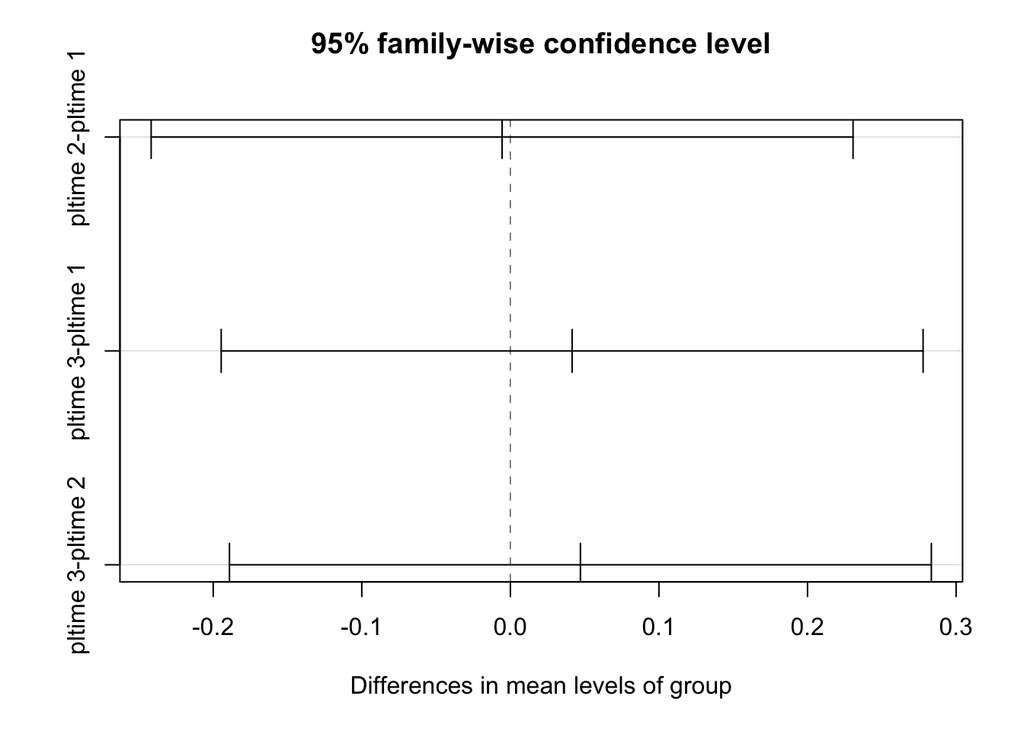

```r
plot(disp_HSD)
```

If we want to visualise the estimated dispersions, we can plot the betadisper object

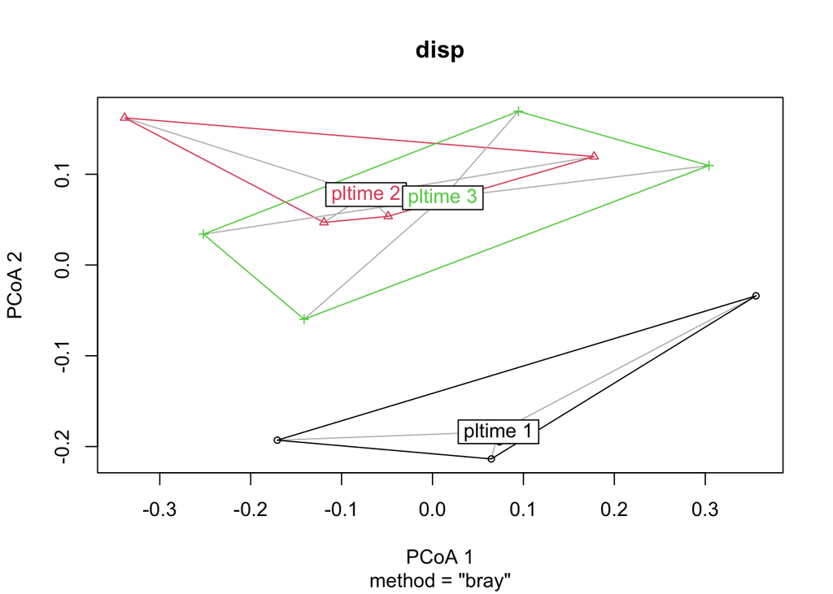

```r
plot(disp)
```

An alternative plot is produced using 1 SD data ellipses

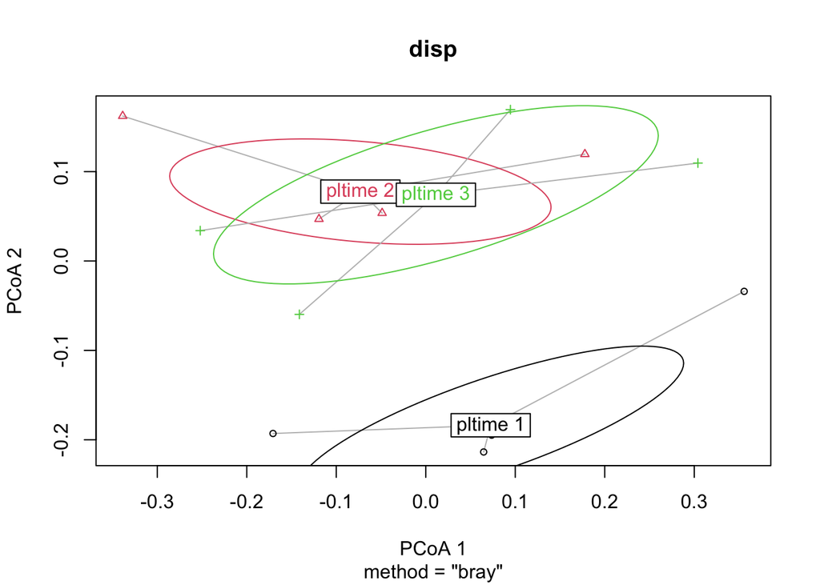

```r
## with data ellipses instead of hulls
plot(disp, ellipse = TRUE, hull = FALSE) # 1 sd data ellipse
```